# NLP Disaster Tweets - Kaggle Mini Project

Nick Vastine  
DTSA 5511 - Introduction to Deep Learning  
Week 4 Assignment  
April 7, 2025

## **Executive Summary**

This project explored recurrent neural networks (RNN) and their ability to process time series data. The project goal was to binary classify whether a tweet were about a disaster. Processing tweet information requires natural language processing to convert the strings into interpretable sequences. The dataset was soured from the [Kaggle 'Natural Language Processing with Disaster Tweets' Competition](https://www.kaggle.com/competitions/nlp-getting-started/submissions).

The project performed standard exploratory analysis before exploring word embedding in depth. This involved processing word embedding data, creating corpos specific vocabularies, and converting tweets to padded word sequences based on word index.

The first project focus compared the generalized word embeddings of GloVe to learned, application-specific embeddings. The application-specific embeddings performed better, quickly fitting the training data and achieving 0.706 test accuracy. The generalized embeddings trained much slower and performed worse on test data with 0.635 accuracy.

Subsequent testing simplified the embeddings, reducing the embedding dimensions and number of RNN units. It was found the initial model of 100 embedding dimensions and 128 RNN units may be overly complex. The rapid rate of training and reasonable validation accuracy was maintained at 16 embedding dimensions and 16 RNN units. Models surprisingly showed limited overfitting, maintaining consistent accuracy despite long training epochs.

Across all testing, it was found that even simple heuristic based models with custom embeddings and a complex single layer RNN can reliably capture training data without dramatic runtime. However, these models can likely be simplified, perhaps instead using computation resources for additional layers rather than additional embedding dimensions or weights. Unsurprisingly, LSTM and GRU ourperform SimpleRNN, though for short tweet sequences the improvements are only marginal.

Future work could consider further modifications to the RNN architecture, including convolutional layers to structure sequences in the RNN or stacking RNN layers to reveal more complex relationships. Other word embedding methods such as BERT could add further resolution to the word embedding process. Additional pre-processing to replace typos or other word errors would also improve model performance. While this project focused on binary classification, the RNN framework can be applied to applications such as tweet sentiment, summarization, or more complex multi-class classification work.

While the technology of RNN appears complex, its implementation in building models is surprisingly simple. RNN's combination with NLP approaches opens an entire world of data science applications.

## **Problem Statement**

The goal of this project is to implement a recurrent neural network (RNN) which can interpret tweets and binary classify whether they relate to disaster events.

The project is based on the [Kaggle Natural Language Processing with Disaster Tweets Competition](https://www.kaggle.com/c/nlp-getting-started/overview).

Interpreting text based tweets is a natural language processing (NLP) problem, requiring methods to capture word sentiment or phrase sentiment through text embedding. Analysis will consider different embedding approaches.

After establishing an embedding approach, hyperparameters for embedding dimension and the number of RNN units will be tuned to improve model performance.

The RNN implementation will also compare standard RNN units to long short-term memory (LSTM) units and Gated Recurrent Units (GRU).

## **Data**

The Kaggle competition provides 3 data sources:

1. `train.csv` - A collection of training data including id, text content, target `{0: Not Disaster, 1: Disaster}`. Additional features such as keywords and location are provided but not used in this project.
2. `test.csv` - A collection of test data which does not include the target label.
3. `sample_submission.csv` - `test.csv` data limited to id and a 0-initiated target field.

The below code imports packages relevant to the project, then imports the data sources.

```python
## Packages
import os
import time
import pandas as pd
import numpy as np
import sklearn as sk
from sklearn.feature_extraction.text import TfidfVectorizer
import matplotlib.pyplot as plt
import seaborn as sns
import tensorflow as tf
from tensorflow.keras import layers, models
from keras.models import Sequential
from keras.layers import Input, Embedding, SimpleRNN, Dense, GRU, LSTM
from tensorflow.keras.preprocessing.text import Tokenizer
from tensorflow.keras.preprocessing.sequence import pad_sequences
```

```python
## Data Import
df_train = pd.read_csv('train.csv')
df_test = pd.read_csv('test.csv')
df_train.head(5)
```

|  | id | keyword | location | text | target |
| --- | --- | --- | --- | --- | --- |
| 0 | 1 | NaN | NaN | Our Deeds are the Reason of this #earthquake M... | 1 |
| 1 | 4 | NaN | NaN | Forest fire near La Ronge Sask. Canada | 1 |
| 2 | 5 | NaN | NaN | All residents asked to 'shelter in place' are ... | 1 |
| 3 | 6 | NaN | NaN | 13,000 people receive #wildfires evacuation or... | 1 |
| 4 | 7 | NaN | NaN | Just got sent this photo from Ruby #Alaska as ... | 1 |

```python
## Sample counts
print(f"Train Samples: {len(df_train)}")
print(f"Test Samples: {len(df_test)}")
```

```
Train Samples: 7613
Test Samples: 3263
```

### Tweet Content

The competition provides 7613 training samples and 3263 testing samples. Below are examples of each class of tweet, highlighting those related to disasters and those that are not.

```python
## Example tweets
print("---Disaster Tweets---",)
for tweet in list(df_train.text[df_train.target ==1][:5]):
    print(f"- {tweet}")
print("")
print("---Non-Disaster Tweets---",)
for tweet in list(df_train.text[df_train.target == 0][:5]):
    print(f"- {tweet}")
```

```
---Disaster Tweets---
- Our Deeds are the Reason of this #earthquake May ALLAH Forgive us all
- Forest fire near La Ronge Sask. Canada
- All residents asked to 'shelter in place' are being notified by officers. No other evacuation or shelter in place orders are expected
- 13,000 people receive #wildfires evacuation orders in California
- Just got sent this photo from Ruby #Alaska as smoke from #wildfires pours into a school

---Non-Disaster Tweets---
- What's up man?
- I love fruits
- Summer is lovely
- My car is so fast
- What a goooooooaaaaaal!!!!!!
```

Humans should easily classify these examples, considering not only the content (wildfires, earthquakes, evacuation), but critically understanding context ("This burrito is *fire!*").

Consider some harder examples printed below. These examples represent cases where a model must understand context beyond word presence. RNNs with memory of surrounding words are one means to achieve this context, as well as other word embedding processes discussed later.

```python
## Example tweets - Harder non-disaster
print("---Harder Non-Disaster Tweets---",)
for tweet in list(df_train.text[(df_train.target == 0) & (df_train.text.str.contains('fire') | df_train.text.str.contains('shelter'))].sample(5)):
    print(f"- {tweet}")
```

```
---Harder Non-Disaster Tweets---
- NowPlaying GT &amp; Wildfire feat. Freaks In Love Feels Like It Should (Original Mix) Massive Dance Radio ListenLive: http://t.co/ANoDGXZR3E
- Tales of the #trees #deep water loving #Lake Tahoe. And no #forest fires https://t.co/xuhMJ098Lq
- Hellfire is surrounded by desires so be careful and donÛªt let your desires control you! #Afterlife #islam
- My asshole is on fire  https://t.co/Y3FO0gHg8t
- Trafford Centre film fans angry after Odeon cinema evacuated following false fire alarm   http://t.co/6GLDwx71DA
```

## **Exploratory Data Analysis**

Before we discuss options for the model to capture context, let's further explore the dataset.

### Length Histograms

First, we can compare the distribution of tweet length for any obvious differences.

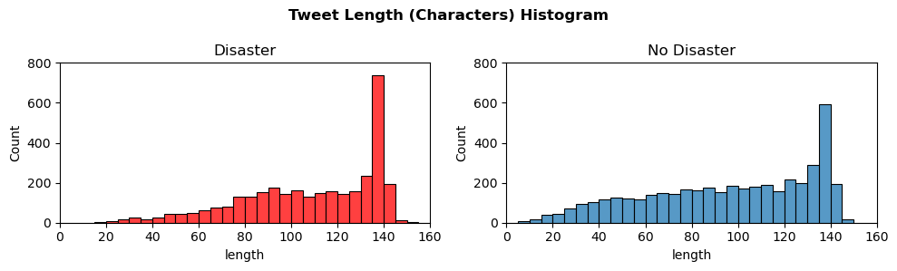

```python
## Tweet Length Histogram
df_train['length'] = df_train['text'].str.len()
fig, axes = plt.subplots(1,2, figsize=(10,3))
fig.suptitle("Tweet Length (Characters) Histogram",fontweight='bold')
axes[0].set_title("Disaster")
axes[0].set_xlim(0,160)
axes[0].set_ylim(0,800)
sns.histplot(df_train[df_train['target']==1], x='length', bins=np.arange(0,165,5), ax=axes[0], color='red')
axes[1].set_title("No Disaster")
axes[1].set_xlim(0,160)
axes[1].set_ylim(0,800)
sns.histplot(df_train[df_train['target']==0], x='length', bins=np.arange(0,165,5), ax=axes[1])
plt.tight_layout()
plt.show()
# df_train.hist(column='length',by='target')
```

Surprisingly most tweets are between 135 and 140 characters in length rather than a smooth distribution. However, both disaster and non-disaster tweets are similarly distributed. Shorter tweets are more likely to be non-disaster than disaster.

We can also consider the number of words in a tweet. Since our network will be based on word sentiment and context, these counts are more representative of what the neural network actually sees.

```
Most Words: 31
```

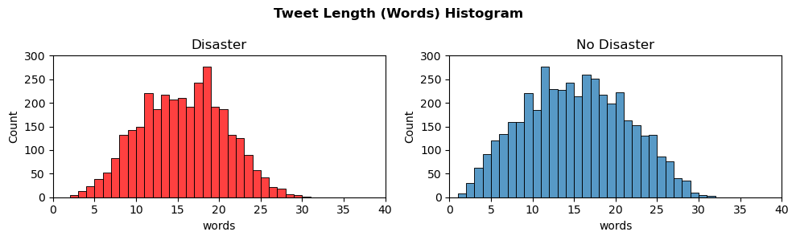

```python
## Tweet Length Histogram
df_train['words'] = df_train['text'].str.split().str.len()
print("Most Words:", df_train['words'].max())
fig, axes = plt.subplots(1,2, figsize=(10,3))
fig.suptitle("Tweet Length (Words) Histogram",fontweight='bold')
axes[0].set_title("Disaster")
axes[0].set_xlim(0,40)
axes[0].set_ylim(0,300)
sns.histplot(df_train[df_train['target']==1], x='words', bins=np.arange(0,36,1), ax=axes[0], color='red')
axes[1].set_title("No Disaster")
axes[1].set_xlim(0,40)
axes[1].set_ylim(0,300)
sns.histplot(df_train[df_train['target']==0], x='words', bins=np.arange(0,36,1), ax=axes[1])
plt.tight_layout()
plt.show()
# df_train.hist(column='length',by='target')
```

Surprisingly, the tweets when organized by number of words follows a more normal distribution. This will help inform our max input length of 40 during model training.

### Training Ratio

Next consider the ratio of positive and negative training samples. The below code indicates a 43%/57% positive/negative proportion from the training data. The subsequent code generates a balanced subsample by removing negative samples, more ideal for model training.

```python
## Training Ratio
def training_ratio(df_train):
    positive_samples = len(df_train[df_train.target ==1])
    negative_samples = len(df_train[df_train.target ==0])
    total_samples = positive_samples + negative_samples
    print(f"Positive Samples: {positive_samples}")
    print(f"Negative Samples: {negative_samples}")
    print(f"Ratio: {round(100*positive_samples/total_samples,1)}% Positive / {round(100*negative_samples/total_samples,1)}% Negative")
df_train = pd.read_csv('train.csv')
training_ratio(df_train)
```

```
Positive Samples: 3271
Negative Samples: 4342
Ratio: 43.0% Positive / 57.0% Negative
```

```python
## Generate balanced training set
df_train_full = df_train.copy()
df_train_subsample_positive = df_train[df_train.target == 1].sample(3271, random_state = 42)
df_train_subsample_negative = df_train[df_train.target == 0].sample(3271, random_state = 42)
df_train_subsample = pd.concat([df_train_subsample_positive,df_train_subsample_negative], axis=0)
df_train = df_train_subsample.sample(len(df_train_subsample), random_state = 42).reset_index(drop=True)
```

```python
## Training Ratio
training_ratio(df_train)
```

```
Positive Samples: 3271
Negative Samples: 3271
Ratio: 50.0% Positive / 50.0% Negative
```

### Analysis approach

From the EDA, the project analysis proceeds as follows:

1. *Understanding of text representation and embedding* - This section explains the need to vectorize our textual content into numbers, and the several approaches to do to.
2. *Basic RNN Model, comparing two text embedding approaches* - The basic RNN model will use a traditional RNN structure, comparing a global text embedding approach to a learned approach.
3. *Hyperparameter tuning* - The model's number of recurrent units and embedding dimensions will be varied.
4. *Alternative RNN structures* - Finally, long short-term memory (LSTM) and gated recurrent units (GRU) will be implemented in simple alternatives to SimpleRNN.

While not considered in the scope of this report, further analysis could add convolutional layers, stack RNN layers, evaluate alternative text embeddings (such as BERT), or apply the technology to different problems for future work.

## **Model Architecture**

While RNN implementation is the main goal of this project, this project also serves an opportunity to explore natural language processing (NLP) methods and technologies. These methods are explored in detail before implementing them for our disaster classification problem.

### Representing Words Numerically

There are a two core problems in natural language processing: 1) words need to be encoded as numbers, 2) those encodings ideally capture the context/sentiment/meaning of a word.

#### One-hot encoding word presence

Consider one-hot encoding of words. Perhaps we have two similar sentences: "I like apples" and "I like bananas". Say we have an input array of all possible words, with 0 indicating a word is absent and 1 when a word is present. For example, `[1,1,1,0]` could represent "I like apples", and `[1,1,0,1]` could represent "I like bananas". If we were evaluating sentiment, perhaps our network could notice the similarities between these samples group them together.

However, consider "I don't like apples" and "I like apples, don't you?". Both samples contain the same words and therefore very similar encodings. However, the *context* of the words are lost taken without order or meaning.

```python
## Consider most frequent words
corpus = list(df_train.text)
text = " ".join(corpus).lower() # Join tweets with space separate. Use lower case for consistency
words = text.split()            # Split long string of all tweets into words
word_count = { }                # Initialize dict
for word in words:
    # Each time a word comes up, call the current total and add 1.
    # Default to 0 if word does not yet exist in dictionary
    word_count[word] = word_count.get(word, 0) + 1
df_word_count = pd.DataFrame.from_dict(word_count, orient='index',columns=['Count'])
print("Distinct words:", len(df_word_count))
print("Single Use words:", len(df_word_count[df_word_count.Count == 1]))
df_word_count.sort_values('Count',ascending=False).head()
```

```
Distinct words: 25023
Single Use words: 18217
```

|  | Count |
| --- | --- |
| the | 2746 |
| a | 1796 |
| in | 1760 |
| to | 1658 |
| of | 1601 |

Unsurprisingly, the most common words aren't that distinguishing. Whether 'the' or 'a' or 'in' is present in a tweet is unlikely to dictate our classification. However, these words *are* important since they provide context and structure to the surrounding words. Consider if the word 'not' was disregarded from our sentiment analysis because it is so common.

Other word presence methods like Term Frequency-Inverse Document Frequency (TF-IDF) calculates the frequency a word is used in a document/tweet and the frequency a word is used across a corpus of all documents/tweets. Words used frequently in one document but not frequently in the corpus score a high TF-IDF, indicating that word helps distinguish that document. This helps reduce the effect of common words, though this process too removes context from the words. A book about apple the fruit and Apple the company may rank "apple" similarly high in TF-IDF.

So how do we contextualize words in general?

#### Text Embedding - Representing Word Meaning as a Vector

Note that one-hot encoding does not identify similarities between words. In the previous example, a model may learn 'apples' and 'bananas' are similar if there are training examples that use them similarly. In the context of disasters, "WARNING: TSUNAMI, SEEK SHELTER" is functionally the same as "WARNING: EARTHQUAKE/TORNADO...". These word similarities between tsunami and earthquake are captured using *text embeddings*.

Imagine yourself in a library looking for a book about World War II. Perhaps you are in the children's section, which hopefully does not have books about World War II. Maybe you look around and locate the history section, then see books about World War I, then books about World War II.

Like organizing books in a libary by subject, imagine placing every word in the human language on an infinitely spanning bookshelf. On the bookshelf, perhaps there is a region of adjectives spanning [-100, -50], verbs from [-25, 25], and nouns from [50, 100]. Within the region of nouns, perhaps there is a section for animals from [75, 80], or fruits from [85, 90]. On this bookshelf, like the Dewey decimal system, every word is assigned a location. "Orange" is [85.2], "lemon" is [85.3], "verbose" is [-75]. Similar words are assigned similar values.

These text embeddings aren't limited to a single dimension. For example, perhaps there is a dimension describing object color, or size, or more abstract qualities like "associated with childhood".

General text embeddings range from 50 to 200 dimensions, locating every word in the human language somewhere within this abstract space, grouping them close to similar words. Some models of text embedding can even capture abstract relationships numerically, such as "king - man + woman = queen".

Interestingly, neural networks learn these text embeddings to assign each word its location. Several pre-trained text embeddings are available for use:

- **GloVe** (Global Vectors for Word Representation) - Uses word-word co-occurence to understand meaning. For example, 'ice' occurs more often with 'solid' than it does with 'gas'. This creates a globally based embedding capturing many types of relationships. (https://nlp.stanford.edu/projects/glove/)
- **Word2Vec** - Means of converting words to dense vector representations. Context words are input and the model is trained to predict the output term. (https://www.analyticsvidhya.com/blog/2021/07/word2vec-for-word-embeddings-a-beginners-guide/)
- **BERT** - Model which can develop contextual embeddings for the same word. For example, apple the fruit and the company should have very different embeddings. Given a sentence context, BERT may use different embeddings for the same word to improve performance. (https://huggingface.co/docs/transformers/en/model_doc/distilbert)

In all these cases, embeddings result from neural network training. As such, we can also train our own embeddings custom to our application.

### Text Embedding Comparison + Building the RNN

The below code constructs two models for comparison:

1. Model 1 uses GloVe-provided text embeddings which capture the general similarity/semantics of each word. The 6B token dataset, including the 100 dimension embedding, is downloadable here: https://nlp.stanford.edu/data/glove.6B.zip
2. Model 2 learns its own text embeddings in the exclusive context of classifying if tweets are about disasters.

Both models are based on a relatively simple neural network. Text embedding is performed as pre-processing step, either initialized from GloVe or learned like any other parameter in a neural network. The data is passed to a 128 unit RNN, where each unit develops its own weights during training. The output of those units is passed to a single dense layer before being sent to a sigmoid classifier for output.

#### Detailed explanation of incorporating pre-built text embeddings.

Unfortunately we cannot simply load our text data into our neural networks. Remember is we aren't learning embeddings from scratch, we need to extract them from a learned dataset. To achieve this, we need to:

1. **Isolate the words relevant to our analysis and tokenize them into an index** - We want to assign each relevant word an index we will use to build our look-up matrix. This process should prioritize frequently used words. The result is our `word_index`.
2. **Extract all possible embeddings from the pre-built embeddings** - Pre-built text embeddings like GloVe are easily downloaded from the internet. These files are formatted like a .csv, with their word in the first column and their subsequent embedding dimensions. For example, the first entry may be [a, 0, 1, ...] up to 100 embedding dimensions. We load these into our `embedding_index`.
3. **Record the embeddings for words within our specified** `vocab_size` - Since our `word_index` is organized by frequency, we look up each word in our `embedding_index` to isolate their `embedding_vector`. We then record that `embedding_vector` in our `embedding_matrix`. Recall we don't need *all* words, just a reasonable vocabulary size prioritizing words used most frequently. As such, repeat this process for our specified `vocab_size`.

The project implements these steps below:

```python
## Shared Parameters
vocab_size = 5000  # Vocabulary size - Note lower than # of distinct words since many words may only be used once.
embedding_dim = 100  # Dimensions for embedding (based on 100 dimensions from GloVe)
```

```python
# Tokenizer - Index each word that appears in tweet content based on word frequency
tokenizer = Tokenizer(num_words=vocab_size, oov_token="<OOV>")
tokenizer.fit_on_texts(df_train.text)

# Vocabulary word index
word_index = tokenizer.word_index

# # Load GloVe embeddings
embedding_index = {}                                     # Initialize dict
with open('glove.6B.100d.txt', encoding='utf-8') as embeddings:
    for line in embeddings:                              # For each line
        values = line.split()                            # Split word and coeffs into a list
        word = values[0]                                 # Extract word
        coefs = np.asarray(values[1:], dtype='float32')  # Extract embeddings
        embedding_index[word] = coefs                    # Write coeffs to dict

# Create the embedding matrix - What is actually used in model
embedding_matrix = np.zeros((vocab_size, embedding_dim))
for word, i in word_index.items():                       # For each word
    if i < vocab_size:                                   # If room for more words
        embedding_vector = embedding_index.get(word)     # Get vector from index based on GloVe
        if embedding_vector is not None:
            embedding_matrix[i] = embedding_vector       # Write vector to matrix assuming it exists
    else:
        break                                            # Break early if vocab_size is met
```

#### Preparing Training Data

Now that we have an embeddings matrix, we need to convert our text strings into something our models can interpret. Using our `word_index`, all tweets can now be represented using those indexes. For example, "I like apples" becomes [3, 35, 100].

However, our neural network is expecting a fixed length input. We achieve this by *padding* our sequences at the end. Our longest tweet is 31 words long, so we will use a maximum length of 40 for good measure. With padding, "I like apples" becomes [3, 35, 100, 0, 0, 0...] out to 40 words.

These padded sequences become the input to our model. We perform the process on our training and testing data before it is fed to our models.

```python
## Training Data

# Convert text to sequences - Represent sequences using the index.
# Ex: [1, 10, 12] where each index corresponds to word from tokenizer
sequences = tokenizer.texts_to_sequences(df_train.text)

# Pad Sequences - Add 0s to make each sequence the same length.
# Ex: [1, 10, 12, 0, 0...] to max length
input_length = 40
padded_sequences = pad_sequences(sequences, maxlen=input_length, padding='post')

# Feed padded sequences as input to the models
X = padded_sequences
Y = df_train['target']

# Prepare Test data
test_sequences = tokenizer.texts_to_sequences(df_test.text)
test_padded_sequences = pad_sequences(test_sequences, maxlen=input_length, padding='post')
X_test = test_padded_sequences
```

#### Building the model

Finally we can build our two models where the only difference occurs in the Embedding layer.

In the GloVe model, we use our pre-built `embedding_matrix` and do not update the weights during training. In the learned embeddings models, the embeddings are randomly intialized and updated through backpropagation during model training. These learned embeddings act as learning parameters, providing an additional 500,000 parameters for the model to adjust.

```python
## GloVe Text Embedding Model
# Define the model
glove_model = Sequential([
    Input(shape=(input_length,)),
    Embedding(input_dim=vocab_size, output_dim=embedding_dim,
              weights=[embedding_matrix], trainable=False),  # GloVe embeddings (frozen)
    SimpleRNN(units=128, return_sequences=False),  # RNN
    Dense(1, activation='sigmoid')  # Classification
])
glove_model.compile(optimizer='adam', loss='binary_crossentropy', metrics=['accuracy','precision','recall'])
glove_model.summary()
```

```
Model: "sequential"
```

```
┏━━━━━━━━━━━━━━━━━━━━━━━━━━━━━━━━━━━━━━┳━━━━━━━━━━━━━━━━━━━━━━━━━━━━━┳━━━━━━━━━━━━━━━━━┓
┃ Layer (type)                         ┃ Output Shape                ┃         Param # ┃
┡━━━━━━━━━━━━━━━━━━━━━━━━━━━━━━━━━━━━━━╇━━━━━━━━━━━━━━━━━━━━━━━━━━━━━╇━━━━━━━━━━━━━━━━━┩
│ embedding (Embedding)                │ (None, 40, 100)             │         500,000 │
├──────────────────────────────────────┼─────────────────────────────┼─────────────────┤
│ simple_rnn (SimpleRNN)               │ (None, 128)                 │          29,312 │
├──────────────────────────────────────┼─────────────────────────────┼─────────────────┤
│ dense (Dense)                        │ (None, 1)                   │             129 │
└──────────────────────────────────────┴─────────────────────────────┴─────────────────┘
```

```
 Total params: 529,441 (2.02 MB)
```

```
 Trainable params: 29,441 (115.00 KB)
```

```
 Non-trainable params: 500,000 (1.91 MB)
```

```python
## Learned Embeddings Model
learn_model = Sequential([
    Input(shape=(input_length,)), #
    Embedding(input_dim=vocab_size, output_dim=embedding_dim, trainable=True),  # Trainable embeddings
    SimpleRNN(units=128, return_sequences=False),  # RNN
    Dense(1, activation='sigmoid')  # Classification
])
learn_model.compile(optimizer='adam', loss='binary_crossentropy', metrics=['accuracy','precision','recall'])
learn_model.summary()
```

```
Model: "sequential_1"
```

```
┏━━━━━━━━━━━━━━━━━━━━━━━━━━━━━━━━━━━━━━┳━━━━━━━━━━━━━━━━━━━━━━━━━━━━━┳━━━━━━━━━━━━━━━━━┓
┃ Layer (type)                         ┃ Output Shape                ┃         Param # ┃
┡━━━━━━━━━━━━━━━━━━━━━━━━━━━━━━━━━━━━━━╇━━━━━━━━━━━━━━━━━━━━━━━━━━━━━╇━━━━━━━━━━━━━━━━━┩
│ embedding_1 (Embedding)              │ (None, 40, 100)             │         500,000 │
├──────────────────────────────────────┼─────────────────────────────┼─────────────────┤
│ simple_rnn_1 (SimpleRNN)             │ (None, 128)                 │          29,312 │
├──────────────────────────────────────┼─────────────────────────────┼─────────────────┤
│ dense_1 (Dense)                      │ (None, 1)                   │             129 │
└──────────────────────────────────────┴─────────────────────────────┴─────────────────┘
```

```
 Total params: 529,441 (2.02 MB)
```

```
 Trainable params: 529,441 (2.02 MB)
```

```
 Non-trainable params: 0 (0.00 B)
```

## **Results & Analysis**

With our models and training data ready to go, we will train for 50 epochs and use 10% of our data as validation. Our first comparison is between GloVe pre-trained embeddings and our application specific embeddings.

```python
## Model Evaluation Function
def model_evaluation(model, train=X, label=Y, epochs=50, batch_size=100):
    '''
    Function which takes an untrained base model, trains it, and returns time to train, model, and log for further analysis.
    Log can be used in epoch_plots function to visualize train/validation progress over epochs.
    '''
    start = time.time()
    clone_model = models.clone_model(model)
    log = clone_model.fit(train, label,
                              epochs = epochs,
                              validation_split=0.10,
                              batch_size = batch_size,
                              verbose=0)
    duration = time.time()-start
    accuracy = log.history['accuracy'][-1]
    val_accuracy = log.history['val_accuracy'][-1]
    ## Print results
    print(f"  Duration:{round(duration,1)}s, Accuracy:{round(accuracy,3)}, Val Accuracy: {round(val_accuracy,3)}")
    return clone_model, log
```

```python
print("Learned Embeddings Model")
learn_model, learn_log = model_evaluation(learn_model)
print("GloVe Embeddings Model")
glove_model, glove_log = model_evaluation(glove_model)
```

```
Learned Embeddings Model
  Duration:78.6s, Accuracy:0.984, Val Accuracy: 0.728
GloVe Embeddings Model
  Duration:69.6s, Accuracy:0.863, Val Accuracy: 0.643
```

```python
## Epoch Plot Function
def epoch_plots(log,suptitle=""):
    '''
    Plots accuracy, precision, recall and loss from model log.
    '''
    params = [log.history['accuracy'],
              log.history.get('precision', []),
              log.history.get('recall', []),
              log.history['loss']]
    val_params = [log.history['val_accuracy'],
                  log.history.get('val_precision', []),
                  log.history.get('val_recall', []),
                  log.history['val_loss']]
    labels = ['Accuracy',
              'Precision',
              'Recall',
              'Binary Cross Entropy Loss']
    epochs = range(1, len(log.history['accuracy']) + 1)  # Epoch numbers

    # Plotting
    fig, axes = plt.subplots(1, 4, figsize=(20, 4))
    for ax, param, val_param, label in zip(axes.flatten(),params,val_params,labels):
        ax.plot(epochs, param, label='Training')
        ax.plot(epochs, val_param, label='Validation')
        ax.set_title(label+' vs Epochs')
        ax.set_xlabel('Epochs')
        ax.set_ylabel(label)
        ax.set_ylim([0,1])
        ax.legend(loc='lower left')
        ax.grid(True)
    fig.suptitle(suptitle, fontweight="bold")
    plt.tight_layout()
    plt.show()
```

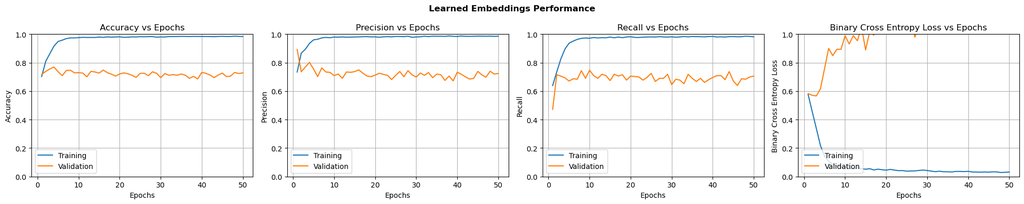

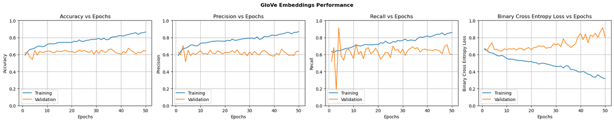

```python
epoch_plots(learn_log, suptitle = "Learned Embeddings Performance")
epoch_plots(glove_log, suptitle = "GloVe Embeddings Performance")
```

Unsurprisingly, the learned embeddings model with 18x as many parameters performs better at this specific classification task. What is surprising, however, is how quickly the model learns and approaches 0.95+ training accuracy. While validation accuracy decreasing indicates overfitting in the Learned Embeddings model, the model still performs better on the validation data than the more generic GloVe Embeddings.

The below code generates a submission for the Kaggle Competition. The learned embeddings model recieved a score of `0.706` and the GloVe model performed worse with a score of `0.635`.

```python
## Generating output
df_sample = pd.read_csv('sample_submission.csv')
Y_test_glove = glove_model.predict(X_test)
df_sample['target'] = np.rint(Y_test_glove).astype(int)
df_sample.to_csv("Glove Predictions.csv", index=False)
Y_test_learn = learn_model.predict(X_test)
df_sample['target'] = np.round(Y_test_learn,0).astype(int)
df_sample.to_csv("Learned Predictions.csv", index=False)
```

```
102/102 ━━━━━━━━━━━━━━━━━━━━ 0s 3ms/step
102/102 ━━━━━━━━━━━━━━━━━━━━ 0s 3ms/step
```

```python
df_sample.head(2)
```

|  | id | target |
| --- | --- | --- |
| 0 | 0 | 0 |
| 1 | 2 | 1 |

### Hyperparameter Tuning

#### Reducing Embedding Dimensions

The next analysis will consider the effects of embedding dimensions on model performance. We will compare the original model with 100 dimensions to a model with 32 and 16 dimensions. This comparison will evaluate if a simpler model can adequately capture each word's importance, and potentially reduce overfitting effects.

```python
## Learned Embeddings Model - Different Embedding Dimensions
learn_32dim_model = Sequential([
    Input(shape=(input_length,)), #
    Embedding(input_dim=vocab_size, output_dim=32, trainable=True),  # Trainable embeddings
    SimpleRNN(units=128, return_sequences=False),  # RNN
    Dense(1, activation='sigmoid')  # Classification
])
learn_32dim_model.compile(optimizer='adam', loss='binary_crossentropy', metrics=['accuracy','precision','recall'])

learn_16dim_model = Sequential([
    Input(shape=(input_length,)), #
    Embedding(input_dim=vocab_size, output_dim=16, trainable=True),  # Trainable embeddings
    SimpleRNN(units=128, return_sequences=False),  # RNN
    Dense(1, activation='sigmoid')  # Classification
])
learn_16dim_model.compile(optimizer='adam', loss='binary_crossentropy', metrics=['accuracy','precision','recall'])
```

```python
print("32 Dim Learned Embeddings Model")
learn_32dim_model, learn_32dim_log = model_evaluation(learn_32dim_model)
print("16 Dim Learned Embeddings Model")
learn_16dim_model, learn_16dim_log = model_evaluation(learn_16dim_model)
```

```
32 Dim Learned Embeddings Model
  Duration:66.8s, Accuracy:0.984, Val Accuracy: 0.698
16 Dim Learned Embeddings Model
  Duration:53.0s, Accuracy:0.979, Val Accuracy: 0.715
```

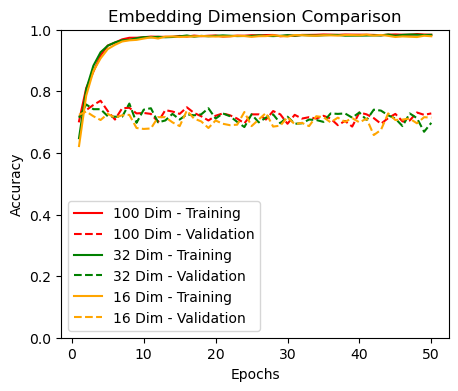

```python
## Embedding Dimension Comparision Plot
epochs = range(1, len(learn_log.history['accuracy']) + 1)
plt.figure(figsize=(5,4))
plt.plot(epochs, learn_log.history['accuracy'], label="100 Dim - Training", color='red')
plt.plot(epochs, learn_log.history['val_accuracy'], label="100 Dim - Validation", color='red', linestyle='dashed')
plt.plot(epochs, learn_32dim_log.history['accuracy'], label="32 Dim - Training", color='green')
plt.plot(epochs, learn_32dim_log.history['val_accuracy'], label="32 Dim - Validation", color='green', linestyle='dashed')
plt.plot(epochs, learn_16dim_log.history['accuracy'], label="16 Dim - Training", color='orange')
plt.plot(epochs, learn_16dim_log.history['val_accuracy'], label="16 Dim - Validation", color='orange', linestyle='dashed')
plt.title("Embedding Dimension Comparison")
plt.ylabel("Accuracy")
plt.xlabel("Epochs")
plt.ylim((0,1))
plt.legend(loc='lower left')
plt.show()
```

#### RNN Units Comparison

Next we will perform a similar comparison varying the number of RNN units. We will compare the original 128 units with 64, 16, and 1 unit.

```python
## Learned Embeddings Model - Different RNN Units Dimensions
learn_16dim_64units_model = Sequential([
    Input(shape=(input_length,)), #
    Embedding(input_dim=vocab_size, output_dim=16, trainable=True),  # Trainable embeddings
    SimpleRNN(units=64, return_sequences=False),  # RNN
    Dense(1, activation='sigmoid')  # Classification
])
learn_16dim_64units_model.compile(optimizer='adam', loss='binary_crossentropy', metrics=['accuracy','precision','recall'])

learn_16dim_16units_model = Sequential([
    Input(shape=(input_length,)), #
    Embedding(input_dim=vocab_size, output_dim=16, trainable=True),  # Trainable embeddings
    SimpleRNN(units=16, return_sequences=False),  # RNN
    Dense(1, activation='sigmoid')  # Classification
])
learn_16dim_16units_model.compile(optimizer='adam', loss='binary_crossentropy', metrics=['accuracy','precision','recall'])

learn_16dim_1unit_model = Sequential([
    Input(shape=(input_length,)), #
    Embedding(input_dim=vocab_size, output_dim=16, trainable=True),  # Trainable embeddings
    SimpleRNN(units=1, return_sequences=False),  # RNN
    Dense(1, activation='sigmoid')  # Classification
])
learn_16dim_1unit_model.compile(optimizer='adam', loss='binary_crossentropy', metrics=['accuracy','precision','recall'])
```

```python
print("64 Units Learned Embeddings Model")
learn_16dim_64units_model, learn_16dim_64units_log = model_evaluation(learn_16dim_64units_model)
print("16 Units Learned Embeddings Model")
learn_16dim_16units_model, learn_16dim_16units_log = model_evaluation(learn_16dim_16units_model)
print("1 Unit Learned Embeddings Model")
learn_16dim_1unit_model, learn_16dim_1unit_log = model_evaluation(learn_16dim_1unit_model)
```

```
64 Units Learned Embeddings Model
  Duration:40.1s, Accuracy:0.983, Val Accuracy: 0.718
16 Units Learned Embeddings Model
  Duration:41.4s, Accuracy:0.985, Val Accuracy: 0.725
1 Unit Learned Embeddings Model
  Duration:39.3s, Accuracy:0.84, Val Accuracy: 0.727
```

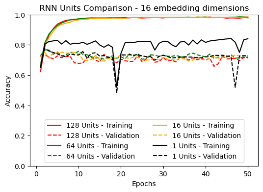

```python
## RNN Units Comparision Plot
epochs = range(1, len(learn_log.history['accuracy']) + 1)
plt.figure(figsize=(6,4))
plt.plot(epochs, learn_16dim_log.history['accuracy'], label="128 Units - Training", color='red')
plt.plot(epochs, learn_16dim_log.history['val_accuracy'], label="128 Units - Validation", color='red', linestyle='dashed')
plt.plot(epochs, learn_16dim_64units_log.history['accuracy'], label="64 Units - Training", color='green')
plt.plot(epochs, learn_16dim_64units_log.history['val_accuracy'], label="64 Units - Validation", color='green', linestyle='dashed')
plt.plot(epochs, learn_16dim_16units_log.history['accuracy'], label="16 Units - Training", color='orange')
plt.plot(epochs, learn_16dim_16units_log.history['val_accuracy'], label="16 Units - Validation", color='orange', linestyle='dashed')
plt.plot(epochs, learn_16dim_1unit_log.history['accuracy'], label="1 Units - Training", color='black')
plt.plot(epochs, learn_16dim_1unit_log.history['val_accuracy'], label="1 Units - Validation", color='black', linestyle='dashed')
plt.title("RNN Units Comparison - 16 embedding dimensions")
plt.ylabel("Accuracy")
plt.xlabel("Epochs")
plt.ylim((0,1))
plt.legend(loc='lower center',ncol=2)
plt.show()
```

The above plot indicates limited sensitivity for the number of RNN units. While the problem's complexity requires a minimum number of RNN units, increasing beyond that threshold does not yield better model performance. For example, 1 unit appears to be below the learning threshold, while 16 units is above. In fact, above that threshold the model has diminishing returns and possible overfitting concerns. Reducing units can reduce model complexity, however regularization techniques can also reduce overfitting concerns while enabling the complex model to represent more comples relationships.

### LSTM and GRU Comparison

Finally we can compare the alternative RNN structures long short-term memory (LSTM) units and gated recurrent units (GRU). Both methods may better capture the long term context of a tweet, especially those longer in length. These alternative models will use 16 units and 16 embedding dimensions to further simplify the model.

```python
## Building LSTM and GRU Models
LSTM_model = Sequential([
    Input(shape=(input_length,)), #
    Embedding(input_dim=vocab_size, output_dim=16, trainable=True),  # Trainable embeddings
    LSTM(units=16, return_sequences=False),  # LSTM
    Dense(1, activation='sigmoid')  # Classification
])
LSTM_model.compile(optimizer='adam', loss='binary_crossentropy', metrics=['accuracy','precision','recall'])

GRU_model = Sequential([
    Input(shape=(input_length,)), #
    Embedding(input_dim=vocab_size, output_dim=16, trainable=True),  # Trainable embeddings
    GRU(units=16, return_sequences=False),  # LSTM
    Dense(1, activation='sigmoid')  # Classification
])
GRU_model.compile(optimizer='adam', loss='binary_crossentropy', metrics=['accuracy','precision','recall'])
```

```python
## Training Models
print("LSTM Model Training")
LSTM_model, LSTM_log = model_evaluation(LSTM_model)
print("GRU Model Training")
GRU_model, GRU_log = model_evaluation(GRU_model)
```

```
LSTM Model Training
  Duration:46.3s, Accuracy:0.982, Val Accuracy: 0.754
GRU Model Training
  Duration:50.3s, Accuracy:0.977, Val Accuracy: 0.751
```

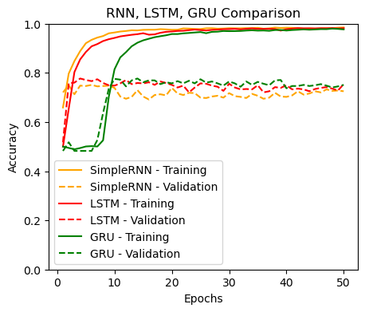

```python
## Plotting Model Performance
## Embedding Dimension Comparision Plot
epochs = range(1, len(learn_log.history['accuracy']) + 1)
plt.figure(figsize=(5,4))
plt.title("RNN, LSTM, GRU Comparison")
plt.plot(epochs, learn_16dim_16units_log.history['accuracy'], label="SimpleRNN - Training", color='orange')
plt.plot(epochs, learn_16dim_16units_log.history['val_accuracy'], label="SimpleRNN - Validation", color='orange', linestyle='dashed')
plt.plot(epochs, LSTM_log.history['accuracy'], label="LSTM - Training", color='red')
plt.plot(epochs, LSTM_log.history['val_accuracy'], label="LSTM - Validation", color='red', linestyle='dashed')
plt.plot(epochs, GRU_log.history['accuracy'], label="GRU - Training", color='green')
plt.plot(epochs, GRU_log.history['val_accuracy'], label="GRU - Validation", color='green', linestyle='dashed')
plt.ylabel("Accuracy")
plt.xlabel("Epochs")
plt.ylim((0,1))
plt.legend(loc='lower left')
plt.show()
```

Interestingly, while SimpleRNN trains the fastest, it also overfits most on the validation data. LSTM performs similarly, though does not overfit as dramatically as SimpleRNN. Finally GRU trains poorly in the first many epochs, but performs on par with LSTM once adequately trained. It is unclear what is causing the delay in training for the GRU model.

## **Conclusion**

This project seeked to use RNN in a binary classification application using NLP.

The project considered the effects of learning text embeddings compared to importing fixed, general text embeddings from GloVe. Unsurprisingly, learned text embeddings performed better for this specific task than general embeddings due to the additional parameters in the model. This however also led to some overfitting, though the learned embeddings validation accuracy performed better than the general GloVe model. An ideal approach may use general embeddings to initialize the embeddings, then allow the model to update weights specific to the task. In this relatively small application however, the model quickly learned embeddings within less than 10 training epochs on only 6,000 training samples.

Finally the simplified model compared performance to alternative RNN structures. While all work had first used the `SimpleRNN` structure, most RNN now use `LSTM` or `GRU`. Again, due to the simplicity of the application (and seemingly large influence of learned embeddings), I did not expect dramatic model improvements. However, while both alternative models trained slightly slower (with GRU plateuing for several epochs before learning), both offered higher validation accuracy without as much overfitting.

Unfortunately many of the experiments did not dramatically improve performance, though they did demonstrate how a simpler model could perform similarly. It is likely the intial model was sufficiently complex to represent the application.

Future work may consider other modifications to the model, such as using convolution layers as a mean to structure sequences fed into the RNN. Like stacking convolution layers, stacking RNN layers may also reveal more complex sequence relationships. This project focused on binary classification, but a similar RNN framework could use unsupervised learning for tweet classification, sentiment, or summarizing fed text. While custom embeddings performed best in this project, it appears BERT or DistilBERT based on Google transformer technology is the industry standard.

While the technology of RNN appears complex, its implementation in building models is surprisingly simple. RNN's combination with NLP approaches opens an entire world of data science applications.

## **References**

- GloVe Explanation - https://nlp.stanford.edu/projects/glove/
- Word2Vec - https://www.analyticsvidhya.com/blog/2021/07/word2vec-for-word-embeddings-a-beginners-guide/
- DistilBERT - https://huggingface.co/docs/transformers/en/model_doc/distilbert

## Appendix

TF-IDF Analysis, which did not seem very useful for this application.

```python
## Perform TF-IDF on Disaster Tweets
# Isolate disaster tweets
disaster_corpus = list(df_train.text)
# Vectorize using TF-IDF
vectorizer = TfidfVectorizer()
tfidf_matrix = vectorizer.fit_transform(disaster_corpus)
# Extract feature names
feature_names = vectorizer.get_feature_names_out()
# Return average TF-IDF score across all disaster tweets
tfidf_scores = tfidf_matrix.toarray().max()
# Combine into dataframe
tfidf_df = pd.DataFrame({'word': feature_names, 'score': tfidf_scores})
print("Top 5 TF-IDF Words From Disaster Tweets:")
tfidf_df.sort_values(by='score', ascending=False).head(5)
```

```
Top 5 TF-IDF Words From Disaster Tweets:
```

|  | word | score |
| --- | --- | --- |
| 19486 | ûówe | 1.0 |
| 0 | 00 | 1.0 |
| 1 | 000 | 1.0 |
| 2 | 0000 | 1.0 |
| 3 | 007npen6lg | 1.0 |